# Averaged vs BLUE phenotypes — how trait construction changes BLINK

**Setup.** Same genotypes (98,026 SNPs), same model (GAPIT/BLINK), same settings. The **only** difference is the trait value fed to GWAS:

- **averaged** — naive environment-average of a genotype's plot records (confounded with *which* environments it was grown in);
- **BLUE** — environment/rep/block-adjusted estimate from a fixed-effects model (the de-confounding fix).

**Question.** Does swapping the phenotype change (1) calibration/inflation, (2) the *number* of hits, and (3) *which* loci BLINK nominates? These are separable:

| Diagnostic | If trait construction is minor | If BLINK is phenotype-sensitive |
| --- | --- | --- |
| λ_GC, QQ, bulk fraction | similar between runs | (may still look similar — BLINK self-calibrates) |
| # significant hits | similar | similar or shifted |
| per-SNP p-value agreement & shared hits | **high** | **low** (different loci) |

**Data:** averaged BLINK = `gapit/results/`; BLUE BLINK = `local_experiments/results_blue/`; all 16 trait×stress combinations, merged on SNP ID. (Locus overlap *within LD windows* is covered separately in `03_ld_decay`; here we compare the runs' statistical character and per-SNP agreement.)

```python
import warnings, glob
from pathlib import Path
import numpy as np, pandas as pd, matplotlib.pyplot as plt
from scipy import stats
warnings.filterwarnings("ignore")
%matplotlib inline
plt.rcParams.update({"figure.dpi": 110, "savefig.dpi": 200, "font.size": 10,
                     "axes.grid": True, "grid.alpha": 0.25})

PROJECT = Path("/path/to/PLANT_PROJECT")
AVG  = PROJECT/"gapit"/"results"                    # averaged-trait BLINK
BLUE = PROJECT/"local_experiments"/"results_blue"   # BLUE-trait BLINK
FIGDIR = PROJECT/"local_experiments"/"figures"; FIGDIR.mkdir(exist_ok=True)

TRAITS = ["yield","anthesis","silking","ASI"]
STRESS = ["NO_STRESS","HEAT_STRESSED","DROUGHT_STRESSED","HEAT_DROUGHT_STRESSED"]
CONDS  = [f"{t}_{s}" for t in TRAITS for s in STRESS]
NSNP   = 98026; BONF = 0.05/NSNP
CHI2_MED = stats.chi2.ppf(0.5, 1)
print("conditions:", len(CONDS), "| Bonferroni p <", f"{BONF:.2e}")
```

```
conditions: 16 | Bonferroni p < 5.10e-07
```

```python
def lambda_gc(p):
    p = np.asarray(p, float); p = p[(p > 0) & (p <= 1)]
    return np.median(stats.chi2.isf(p, 1)) / CHI2_MED

def bulk_fracs(p):
    p = np.asarray(p, float); p = p[(p > 0) & (p <= 1)]
    return {"p<=0.5": (p<=0.5).mean(), "p<=0.1": (p<=0.1).mean(),
            "p<=0.05": (p<=0.05).mean(), "p<=0.01": (p<=0.01).mean()}

def qq_xy(p):
    p = np.sort(np.asarray(p, float)); p = p[(p > 0) & (p <= 1)]; n = len(p)
    return -np.log10((np.arange(1, n+1)-0.5)/n), -np.log10(p)

def load_blink(base, cond):
    g = [x for x in glob.glob(str(Path(base)/f"{cond}_BLINK"/"GAPIT.Association.GWAS_Results.BLINK.*.csv"))
         if "(NYC)" not in x]
    if not g: return None
    df = pd.read_csv(g[0], usecols=["SNP","Chr","Pos","P.value"])
    df["P.value"] = pd.to_numeric(df["P.value"], errors="coerce")
    return df.dropna(subset=["SNP","P.value"])

print("helpers ready")
```

```
helpers ready
```

## 1. Load & inventory

```python
A, B = {}, {}
rows = []
for c in CONDS:
    a, b = load_blink(AVG, c), load_blink(BLUE, c)
    if a is not None: A[c] = a
    if b is not None: B[c] = b
    rows.append({"condition": c,
                 "avg_snps":  len(a) if a is not None else 0,
                 "blue_snps": len(b) if b is not None else 0,
                 "avg_sig":   int((a["P.value"]<BONF).sum()) if a is not None else 0,
                 "blue_sig":  int((b["P.value"]<BONF).sum()) if b is not None else 0})
inv = pd.DataFrame(rows).set_index("condition")
print(f"averaged loaded: {len(A)}/16   BLUE loaded: {len(B)}/16")
print(f"total Bonferroni hits — averaged: {inv.avg_sig.sum()}   BLUE: {inv.blue_sig.sum()}")
inv
```

```
averaged loaded: 16/16   BLUE loaded: 16/16
total Bonferroni hits — averaged: 453   BLUE: 417
```

| condition | avg_snps | blue_snps | avg_sig | blue_sig |
| --- | --- | --- | --- | --- |
| yield_NO_STRESS | 98026 | 98026 | 29 | 25 |
| yield_HEAT_STRESSED | 98026 | 98026 | 18 | 12 |
| yield_DROUGHT_STRESSED | 98026 | 98026 | 4 | 5 |
| yield_HEAT_DROUGHT_STRESSED | 98026 | 98026 | 16 | 9 |
| anthesis_NO_STRESS | 98026 | 98026 | 108 | 62 |
| anthesis_HEAT_STRESSED | 98026 | 98026 | 33 | 36 |
| anthesis_DROUGHT_STRESSED | 98026 | 98026 | 3 | 14 |
| anthesis_HEAT_DROUGHT_STRESSED | 98026 | 98026 | 47 | 38 |
| silking_NO_STRESS | 98026 | 98026 | 46 | 86 |
| silking_HEAT_STRESSED | 98026 | 98026 | 32 | 17 |
| silking_DROUGHT_STRESSED | 98026 | 98026 | 12 | 4 |
| silking_HEAT_DROUGHT_STRESSED | 98026 | 98026 | 45 | 52 |
| ASI_NO_STRESS | 98026 | 98026 | 25 | 21 |
| ASI_HEAT_STRESSED | 98026 | 98026 | 16 | 22 |
| ASI_DROUGHT_STRESSED | 98026 | 98026 | 8 | 6 |
| ASI_HEAT_DROUGHT_STRESSED | 98026 | 98026 | 11 | 8 |

## 2. Calibration — λ_GC, QQ, bulk

Are the two runs differently inflated? λ_GC = median(χ²)/0.4549 (≈1 = calibrated). BLINK absorbs polygenic background into pseudo-QTN covariates, so both runs are expected to be near-calibrated — the point is to confirm the phenotype swap doesn't *break* that, so any later differences are about *which* loci, not inflation.

|  | lambda_avg | lambda_blue |
| --- | --- | --- |
| yield_NO_STRESS | 1.221 | 1.123 |
| yield_HEAT_STRESSED | 1.109 | 1.347 |
| yield_DROUGHT_STRESSED | 1.083 | 1.119 |
| yield_HEAT_DROUGHT_STRESSED | 1.011 | 1.036 |
| anthesis_NO_STRESS | 2.000 | 1.151 |
| anthesis_HEAT_STRESSED | 1.360 | 1.348 |
| anthesis_DROUGHT_STRESSED | 0.959 | 0.779 |
| anthesis_HEAT_DROUGHT_STRESSED | 0.973 | 1.038 |
| silking_NO_STRESS | 1.174 | 1.618 |
| silking_HEAT_STRESSED | 0.997 | 1.067 |
| silking_DROUGHT_STRESSED | 0.902 | 0.817 |
| silking_HEAT_DROUGHT_STRESSED | 1.043 | 1.212 |
| ASI_NO_STRESS | 1.088 | 1.119 |
| ASI_HEAT_STRESSED | 1.261 | 1.178 |
| ASI_DROUGHT_STRESSED | 0.895 | 1.221 |
| ASI_HEAT_DROUGHT_STRESSED | 1.116 | 1.010 |

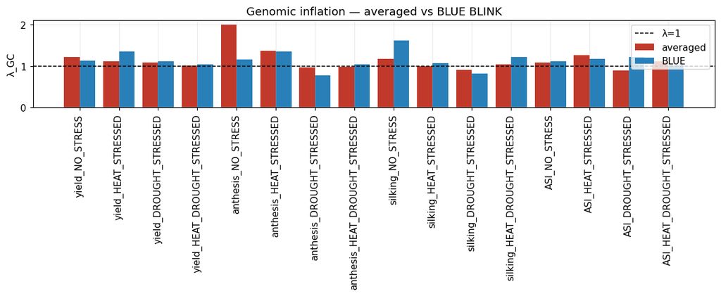

```python
lam = pd.DataFrame({c: {"lambda_avg": lambda_gc(A[c]["P.value"]) if c in A else np.nan,
                        "lambda_blue": lambda_gc(B[c]["P.value"]) if c in B else np.nan}
                    for c in CONDS}).T
display(lam.round(3))
fig, ax = plt.subplots(figsize=(11,4.5)); x = np.arange(len(lam)); w = 0.4
ax.bar(x-w/2, lam.lambda_avg,  w, label="averaged", color="#c0392b")
ax.bar(x+w/2, lam.lambda_blue, w, label="BLUE",     color="#2980b9")
ax.axhline(1, color="k", ls="--", lw=1, label="λ=1")
ax.set_xticks(x); ax.set_xticklabels(lam.index, rotation=90); ax.set_ylabel("λ_GC")
ax.set_title("Genomic inflation — averaged vs BLUE BLINK"); ax.legend()
fig.tight_layout(); fig.savefig(FIGDIR/"avgblue_lambda.png", bbox_inches="tight"); plt.show()
```

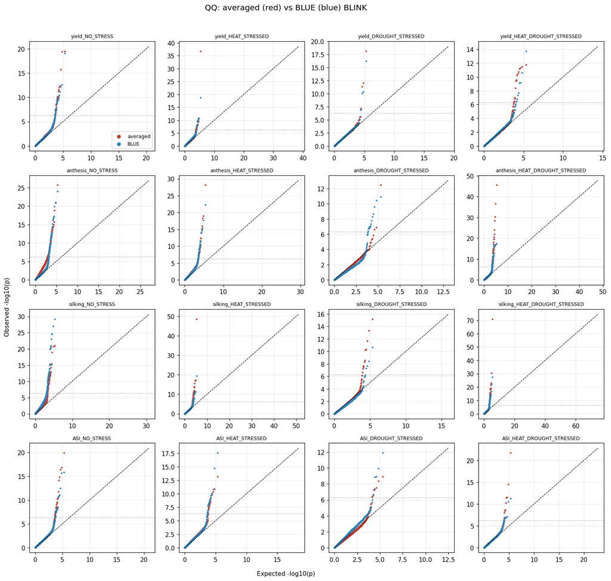

```python
fig, axes = plt.subplots(4, 4, figsize=(15, 14)); bonf = -np.log10(BONF)
for ax, c in zip(axes.ravel(), CONDS):
    if c in A: e,o = qq_xy(A[c]["P.value"]); ax.scatter(e,o,s=3,color="#c0392b",label="averaged",rasterized=True)
    if c in B: e,o = qq_xy(B[c]["P.value"]); ax.scatter(e,o,s=3,color="#2980b9",label="BLUE",rasterized=True)
    hi = max(ax.get_xlim()[1], ax.get_ylim()[1]); ax.plot([0,hi],[0,hi],"k--",lw=0.8)
    ax.axhline(bonf, color="grey", ls=":", lw=0.8); ax.set_title(c, fontsize=8)
axes.ravel()[0].legend(markerscale=3, fontsize=8)
fig.text(0.5,0.06,"Expected -log10(p)",ha="center"); fig.text(0.07,0.5,"Observed -log10(p)",va="center",rotation="vertical")
fig.suptitle("QQ: averaged (red) vs BLUE (blue) BLINK", y=0.995, fontsize=13)
fig.tight_layout(rect=[0.08,0.07,1,0.98]); fig.savefig(FIGDIR/"avgblue_qq.png", bbox_inches="tight"); plt.show()
```

```python
# mean bulk fraction across conditions, per run, vs the null expectation
summ = pd.DataFrame({
  "averaged": pd.DataFrame({c: bulk_fracs(A[c]["P.value"]) for c in CONDS if c in A}).T.mean(),
  "BLUE":     pd.DataFrame({c: bulk_fracs(B[c]["P.value"]) for c in CONDS if c in B}).T.mean(),
  "null":     pd.Series({"p<=0.5":0.5,"p<=0.1":0.1,"p<=0.05":0.05,"p<=0.01":0.01})})
print("mean bulk fraction across conditions (vs null):"); display(summ.round(3))
```

```
mean bulk fraction across conditions (vs null):
```

|  | averaged | BLUE | null |
| --- | --- | --- | --- |
| p<=0.5 | 0.522 | 0.523 | 0.50 |
| p<=0.1 | 0.120 | 0.122 | 0.10 |
| p<=0.05 | 0.066 | 0.066 | 0.05 |
| p<=0.01 | 0.017 | 0.017 | 0.01 |

## 3. Do they find the *same* loci? — per-SNP agreement & shared hits

Merge the two runs on SNP. **Spearman of −log₁₀(p)** measures whether the genome-wide signal *ranks* agree; **shared Bonferroni hits** measures top-hit overlap. High = the phenotype swap barely matters; low = BLINK nominates different loci depending on how the trait was built.

```python
rows = []; scatter = []
for c in CONDS:
    if c not in A or c not in B: continue
    mg = A[c][["SNP","P.value"]].merge(B[c][["SNP","P.value"]], on="SNP", suffixes=("_avg","_blue"))
    if mg.empty: continue
    rho = stats.spearmanr(-np.log10(mg["P.value_avg"]), -np.log10(mg["P.value_blue"])).correlation
    sa, sb = mg["P.value_avg"]<BONF, mg["P.value_blue"]<BONF
    rows.append({"condition":c, "avg_sig":int(sa.sum()), "blue_sig":int(sb.sum()),
                 "shared_sig":int((sa & sb).sum()), "spearman_-log10p":round(rho,3)})
    scatter.append((c, mg))
agree = pd.DataFrame(rows).set_index("condition")
display(agree)
T = agree.sum(numeric_only=True)
print(f"\nTOTAL: averaged {int(T.avg_sig)} hits, BLUE {int(T.blue_sig)} hits, shared {int(T.shared_sig)} "
      f"({100*T.shared_sig/max(T.blue_sig,1):.1f}% of BLUE)")
print(f"median per-SNP -log10p Spearman across conditions: {agree['spearman_-log10p'].median():.3f}")
```

| condition | avg_sig | blue_sig | shared_sig | spearman_-log10p |
| --- | --- | --- | --- | --- |
| yield_NO_STRESS | 29 | 25 | 1 | 0.071 |
| yield_HEAT_STRESSED | 18 | 12 | 0 | 0.062 |
| yield_DROUGHT_STRESSED | 4 | 5 | 0 | 0.023 |
| yield_HEAT_DROUGHT_STRESSED | 16 | 9 | 1 | 0.118 |
| anthesis_NO_STRESS | 108 | 62 | 0 | 0.001 |
| anthesis_HEAT_STRESSED | 33 | 36 | 0 | 0.007 |
| anthesis_DROUGHT_STRESSED | 3 | 14 | 1 | 0.089 |
| anthesis_HEAT_DROUGHT_STRESSED | 47 | 38 | 1 | 0.037 |
| silking_NO_STRESS | 46 | 86 | 1 | -0.002 |
| silking_HEAT_STRESSED | 32 | 17 | 0 | 0.009 |
| silking_DROUGHT_STRESSED | 12 | 4 | 3 | 0.065 |
| silking_HEAT_DROUGHT_STRESSED | 45 | 52 | 0 | 0.011 |
| ASI_NO_STRESS | 25 | 21 | 3 | 0.079 |
| ASI_HEAT_STRESSED | 16 | 22 | 1 | 0.207 |
| ASI_DROUGHT_STRESSED | 8 | 6 | 3 | 0.262 |
| ASI_HEAT_DROUGHT_STRESSED | 11 | 8 | 0 | 0.143 |

```
TOTAL: averaged 453 hits, BLUE 417 hits, shared 15 (3.6% of BLUE)
median per-SNP -log10p Spearman across conditions: 0.064
```

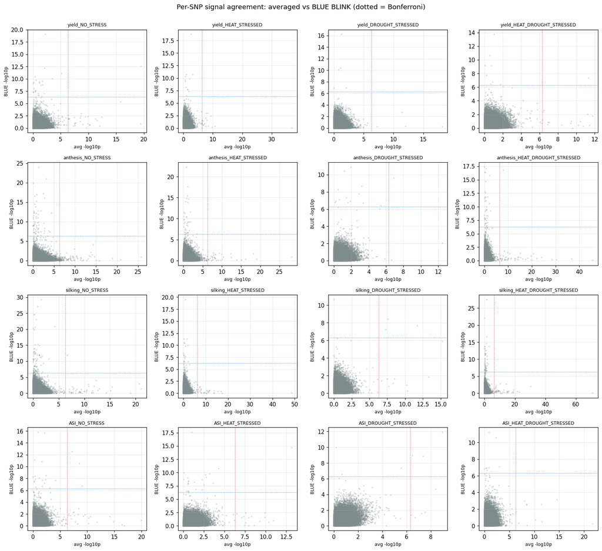

```python
n = len(scatter); ncol = 4; nrow = int(np.ceil(n/ncol))
fig, axes = plt.subplots(nrow, ncol, figsize=(15, 3.4*nrow), squeeze=False)
for ax,(c,mg) in zip(axes.ravel(), scatter):
    x = -np.log10(mg["P.value_avg"]); y = -np.log10(mg["P.value_blue"])
    ax.scatter(x, y, s=3, alpha=0.2, color="#7f8c8d", rasterized=True)
    bl = -np.log10(BONF); ax.axhline(bl, color="#2980b9", ls=":", lw=0.8); ax.axvline(bl, color="#c0392b", ls=":", lw=0.8)
    ax.set_title(c, fontsize=8); ax.set_xlabel("avg -log10p", fontsize=8); ax.set_ylabel("BLUE -log10p", fontsize=8)
for ax in axes.ravel()[n:]: ax.axis("off")
fig.suptitle("Per-SNP signal agreement: averaged vs BLUE BLINK (dotted = Bonferroni)", y=1.0, fontsize=12)
fig.tight_layout(); fig.savefig(FIGDIR/"avgblue_concordance.png", bbox_inches="tight"); plt.show()
```

## 4. Summary

**Implication.** BLINK's locus selection is **highly sensitive to phenotype construction** in this panel; the trait-building choice must be fixed and justified before its loci are treated as findings. (Positional locus overlap within the LD-derived ±16/±32 kb windows is quantified in `03_ld_decay`.)